# Financial Times Series Analysis Lab 1

Kelvin Nyongesa

2023-05-11

#Reading the data and converting into a data frame

```r
library(readxl)
cbk <- read_excel('C:/Users/DELL LATITUDE E7270/Music/investingcom.xlsx')
cbkdata<-as.ts(cbk)
```

#Create a time series plot for each exchange rate

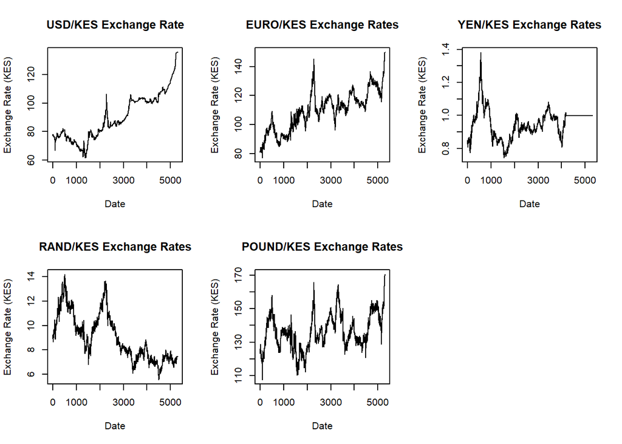

```r
par(mfrow=c(2, 3))
ts.plot(subset(cbkdata, select = USD),main = "USD/KES Exchange Rate",ylab = "Exchange Rate (KES)",xlab = "Date")

ts.plot(subset(cbkdata, select = EURO),main = "EURO/KES Exchange Rates",ylab = "Exchange Rate (KES)",xlab = "Date")

ts.plot(subset(cbkdata, select = YEN),main = "YEN/KES Exchange Rates",ylab = "Exchange Rate (KES)",xlab = "Date")

ts.plot(subset(cbkdata, select = RAND),main = "RAND/KES Exchange Rates",ylab = "Exchange Rate (KES)",xlab = "Date")

ts.plot(subset(cbkdata, select = POUND),main = "POUND/KES Exchange Rates",ylab = "Exchange Rate (KES)",xlab = "Date")
```

#Create a time series plot for all exchange rates

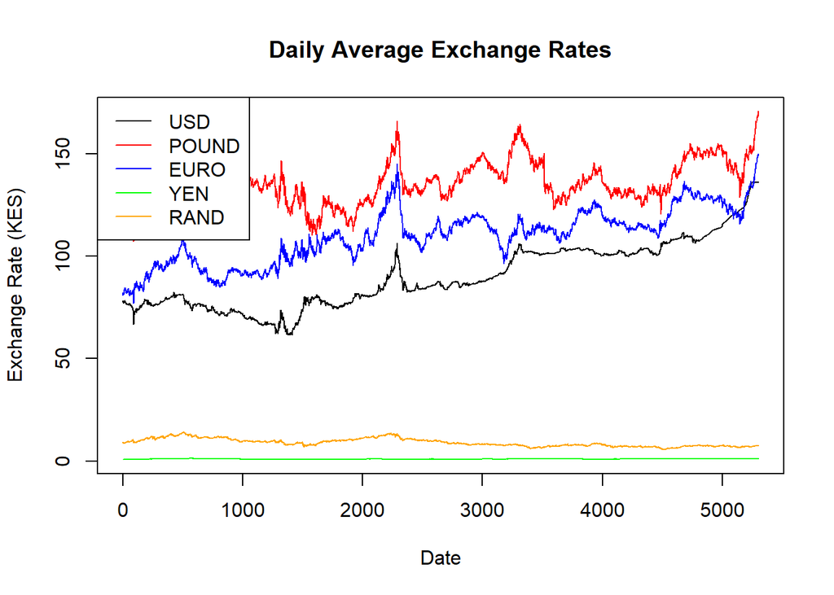

```r
# create a vector of colors to match the plot
colors <- c("black", "red", "blue", "green", "orange")

# plot the time series
ts.plot(subset(cbkdata, select = c(USD, POUND, EURO, YEN, RAND)),main = "Daily Average Exchange Rates",ylab = "Exchange Rate (KES)",xlab = "Date",col = colors)

# add a legend to the plot
legend("topleft",
       legend = c("USD", "POUND", "EURO", "YEN", "RAND"),
       col = colors,
       lty = 1)
```

#Calculate simple returns for each exchange rate,Convert returns to percentages and Compute summary statistics for each exchange rate’s simple returns in percentages

```r
# Calculate simple returns for each exchange rate
ret_usd <- diff(subset(cbkdata, select = USD)) / subset(cbkdata, select = USD)[-nrow(cbkdata)]
ret_ukp <- diff(subset(cbkdata, select = POUND)) / subset(cbkdata, select = POUND)[-nrow(cbkdata)]
ret_eur <- diff(subset(cbkdata, select = EURO)) / subset(cbkdata, select = EURO)[-nrow(cbkdata)]
ret_jpy <- diff(subset(cbkdata, select = YEN)) / subset(cbkdata, select = YEN)[-nrow(cbkdata)]
ret_zar <- diff(subset(cbkdata, select = RAND)) / subset(cbkdata, select = RAND)[-nrow(cbkdata)]

# Convert returns to percentages
ret_usd_pct <- ret_usd * 100
ret_ukp_pct <- ret_ukp * 100
ret_eur_pct <- ret_eur * 100
ret_jpy_pct <- ret_jpy * 100
ret_zar_pct <- ret_zar * 100


# Compute summary statistics for each exchange rate's simple returns in percentages
library("fBasics")
stats <- data.frame(
  `US DOLLAR` = c(mean(ret_usd_pct), sd(ret_usd_pct), skewness(ret_usd_pct), kurtosis(ret_usd_pct, type = "excess"), min(ret_usd_pct), max(ret_usd_pct)),
  `STG POUND` = c(mean(ret_ukp_pct), sd(ret_ukp_pct), skewness(ret_ukp_pct), kurtosis(ret_ukp_pct, type = "excess"), min(ret_ukp_pct), max(ret_ukp_pct)),
  EURO = c(mean(ret_eur_pct), sd(ret_eur_pct), skewness(ret_eur_pct), kurtosis(ret_eur_pct, type = "excess"), min(ret_eur_pct), max(ret_eur_pct)),
  YEN = c(mean(ret_jpy_pct), sd(ret_jpy_pct), skewness(ret_jpy_pct), kurtosis(ret_jpy_pct, type = "excess"), min(ret_jpy_pct), max(ret_jpy_pct)),
  RAND = c(mean(ret_zar_pct), sd(ret_zar_pct), skewness(ret_zar_pct), kurtosis(ret_zar_pct, type = "excess"), min(ret_zar_pct), max(ret_zar_pct))
)

# Label the rows with the respective statistic names
row.names(stats) <- c("Mean", "Standard Deviation", "Skewness", "Excess Kurtosis", "Minimum", "Maximum")

# Print the summary statistics in a table
print(stats)
```

```
##                      US.DOLLAR    STG.POUND        EURO          YEN
## Mean                0.01147763  0.008463099  0.01410577  0.005886588
## Standard Deviation  0.42415190  0.715383920  0.70361615  0.757318905
## Skewness            0.45566920 -0.144827911  0.47672296  0.398941754
## Excess Kurtosis    25.52021005  6.606448559  5.49211517 26.083782085
## Minimum            -4.50966356 -7.967234060 -3.91277259 -6.624233852
## Maximum             5.64263323  5.378770544  6.60580021  6.963201586
##                             RAND
## Mean                 0.002592044
## Standard Deviation   1.152563204
## Skewness            -0.368844958
## Excess Kurtosis      8.547115947
## Minimum            -15.042117930
## Maximum              8.923512748
```

#Transform the simple returns into log return

```r
######
library(fBasics)
###########################################
# Transform the simple returns into log returns
log_ret_usd <- log(1 + (ret_usd_pct/100))  ##We divide by 100 as they were percentages
log_ret_ukp <- log(1 + (ret_ukp_pct/100))##And we want to avoid the NA
log_ret_eur <- log(1 + (ret_eur_pct/100))
log_ret_jpy <- log(1 + (ret_jpy_pct/100))
log_ret_zar <- log(1 + (ret_zar_pct/100))


# Compute summary statistics for each exchange rate's log returns
log_stats <- data.frame(
  USD = c(mean(log_ret_usd), var(log_ret_usd), skewness(log_ret_usd), kurtosis(log_ret_usd, type = "excess"), min(log_ret_usd), max(log_ret_usd)),
  UKP = c(mean(log_ret_ukp), var(log_ret_ukp), skewness(log_ret_ukp), kurtosis(log_ret_ukp, type = "excess"), min(log_ret_ukp), max(log_ret_ukp)),
  EURO = c(mean(log_ret_eur), var(log_ret_eur), skewness(log_ret_eur), kurtosis(log_ret_eur, type = "excess"), min(log_ret_eur), max(log_ret_eur)),
  YEN = c(mean(log_ret_jpy), var(log_ret_jpy), skewness(log_ret_jpy), kurtosis(log_ret_jpy, type = "excess"), min(log_ret_jpy), max(log_ret_jpy)),
  RAND = c(mean(log_ret_zar), var(log_ret_zar), skewness(log_ret_zar), kurtosis(log_ret_zar, type = "excess"), min(log_ret_zar), max(log_ret_zar))
)

# Label the rows with the respective statistic names
row.names(log_stats) <- c("Mean", "Variance", "Skewness", "Excess Kurtosis", "Minimum", "Maximum")

# Print the summary statistics in a table
print(log_stats)
```

```
##                           USD           UKP          EURO           YEN
## Mean             0.0001057876  5.902378e-05  0.0001163558  3.023029e-05
## Variance         0.0000179599  5.124465e-05  0.0000493457  5.725954e-05
## Skewness         0.2830937153 -2.394024e-01  0.4014768723  8.226552e-02
## Excess Kurtosis 25.1246047401  7.037416e+00  5.2181917814  2.590433e+01
## Minimum         -0.0461451328 -8.302552e-02 -0.0399137882 -6.853834e-02
## Maximum          0.0548918276  5.239101e-02  0.0639677353  6.731468e-02
##                          RAND
## Mean            -4.072626e-05
## Variance         1.335935e-04
## Skewness        -5.646356e-01
## Excess Kurtosis  1.033853e+01
## Minimum         -1.630146e-01
## Maximum          8.547573e-02
```

#Testing log return hypothesis

```r
# Perform a two-sided t-test for each exchange rate's log returns
t_test_usd <- t.test(log_ret_usd, mu = 0)
t_test_ukp <- t.test(log_ret_ukp, mu = 0)
t_test_eur <- t.test(log_ret_eur, mu = 0)
t_test_jpy <- t.test(log_ret_jpy, mu = 0)
t_test_zar <- t.test(log_ret_zar, mu = 0)

# Extract the p-values from each t-test
p_values <- c(t_test_usd$p.value, t_test_ukp$p.value, t_test_eur$p.value, t_test_jpy$p.value, t_test_zar$p.value)

# Print the p-values
print(p_values)
```

```
## [1] 0.06923147 0.54835745 0.22792049 0.77118394 0.79755995
```

conclusion Since all of the p-values are greater than 0.05, we fail to reject the null hypothesis at the 5% significance level. This means that there is not enough evidence to conclude that the mean log return of any of the exchange rates is statistically different from zero. However, it is important to note that the absence of evidence for a difference does not necessarily imply evidence of absence of a difference. Therefore, further research may be needed to draw a more definitive conclusion.

#Plotting the Histogram of daily simple and log returns of the above data. Compare them with normal distributions that have the same mean and standard deviation.

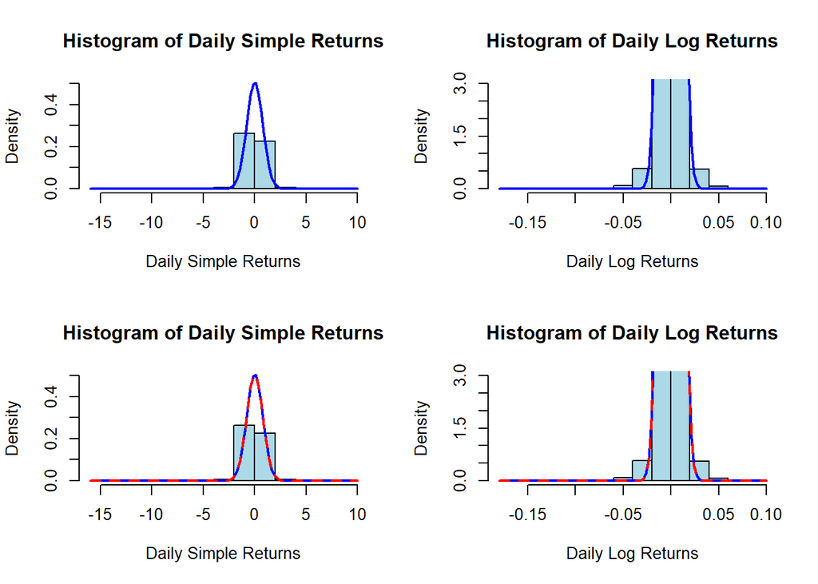

```r
##histogram plot
##Calculate the mean and standard deviation of the simple and log returns:

simple_returns<-c(ret_usd_pct,ret_ukp_pct,ret_eur_pct,ret_jpy_pct,ret_zar_pct)
log_returns<- c(log_ret_usd,log_ret_ukp,log_ret_eur,log_ret_jpy,log_ret_zar )
mean_simple <- mean(simple_returns)
sd_simple <- sd(simple_returns)
mean_log <- mean(log_returns)
sd_log <- sd(log_returns)
#####
# Compute mean and standard deviation of simple and log returns
mean_simple <- mean(simple_returns)
sd_simple <- sd(simple_returns)
mean_log <- mean(log_returns)
sd_log <- sd(log_returns)

par(mfrow = c(2, 2))

# Histogram of daily simple returns
hist(simple_returns, main = "Histogram of Daily Simple Returns", xlab = "Daily Simple Returns", col = "lightblue", freq = FALSE, ylim = c(0, 0.5))
curve(dnorm(x, mean_simple, sd_simple), add = TRUE, col = "blue", lwd = 2)

# Histogram of daily log returns
hist(log_returns, main = "Histogram of Daily Log Returns", xlab = "Daily Log Returns", col = "lightblue", freq = FALSE, ylim = c(0, 3))
curve(dnorm(x, mean_log, sd_log), add = TRUE, col = "blue", lwd = 2)

# Comparison of simple returns with normal distribution
hist(simple_returns, main = "Histogram of Daily Simple Returns", xlab = "Daily Simple Returns", col = "lightblue", freq = FALSE, ylim = c(0, 0.5))
curve(dnorm(x, mean_simple, sd_simple), add = TRUE, col = "blue", lwd = 2)
curve(dnorm(x, mean_simple, sd_simple), add = TRUE, col = "red", lwd = 2, lty = 2)

# Comparison of log returns with normal distribution
hist(log_returns, main = "Histogram of Daily Log Returns", xlab = "Daily Log Returns", col = "lightblue", freq = FALSE, ylim = c(0, 3))
curve(dnorm(x, mean_log, sd_log), add = TRUE, col = "blue", lwd = 2)
curve(dnorm(x, mean_log, sd_log), add = TRUE, col = "red", lwd = 2, lty = 2)
```

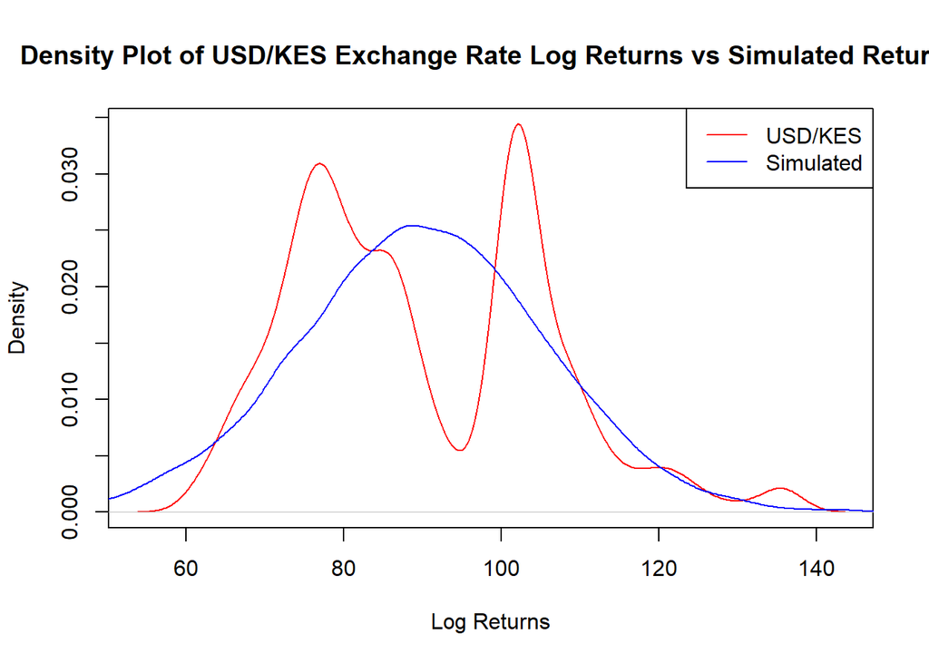

```r
set.seed(123) # for reproducibility
usd <- subset(cbkdata,select= USD) # extract the USD/KES exchange rate log returns from the dataframe
usd_mean <- mean(usd) # calculate the mean of the log returns
usd_sd <- sd(usd) # calculate the standard deviation of the log returns
simulated_returns <- rnorm(5301, mean = usd_mean, sd = usd_sd) # generate 2500 random samples

library(fBasics)
plot(density(usd), col = "red", main = "Density Plot of USD/KES Exchange Rate Log Returns vs Simulated Returns",
     xlab = "Log Returns", ylab = "Density")
lines(density(simulated_returns), col = "blue")
legend("topright", legend = c("USD/KES", "Simulated"), col = c("red", "blue"), lty = 1)
```

```r
#10
library(tseries)
# Compute the Jarque-Bera test statistic and p-value
jbtest <- jarque.bera.test(log_returns)
jbstat <- jbtest$jb[1]

jbpval <- jbtest$p.value[1]

# Print the test results
cat("Jarque-Bera test results:\n")
```

```
## Jarque-Bera test results:
```

```r
cat("Test statistic: ", jbstat, "\n")
```

```
## Test statistic:
```

```r
cat("p-value: ", jbpval, "\n")
```

```
## p-value:  0
```

```r
# Check if null hypothesis is rejected at 5% significance level
if (jbpval < 0.05) {
  cat("Null hypothesis rejected. Log returns are not normally distributed.\n")
} else {
  cat("Null hypothesis not rejected. Log returns may be normally distributed.\n")
}
```

```
## Null hypothesis rejected. Log returns are not normally distributed.
```